# Opportunity for Income Predictor subgroups, county-level

Author

JP Walsh

Published

March 3, 2026

*Program for the creation of the Opportunity for Income Predictor subgroups at the county level*

ACS Code: Initially written by Tina Chelidze and updated by JP Walsh in 2022-2023 and 2025.

Primary data derived from the IPUMS API.

Based on processes developed by Paul Johnson and Kevin Werner in SAS.

*Internal users* If you are an internal tester using the AWS feature of this program remember to enter the passkey into your environment using Sys.setenv(). Authentication steps are nicely explained in this [blog](https://www.gormanalysis.com/blog/connecting-to-aws-s3-with-r/). You will have to request access to the access key.

*User warning* The ACS micro data used to create this metric is large and will take time to read in. It is strongly recommended that you use a server with significant computing power to run this.

Please check that no folders in the filepath that you have cloned this repository to include the acronym “UMF” - this will throw an error from the extract_ipums_aws function. To check your file path you can use the function here::here().

*User warnings*

```
+ The ACS micro data used to create this metric is large and will take time to read in. It is strongly recommended that you use a server with large computing power to run this.
 + Please check that no folders in the filepath that you have cloned this repostiory to include the acronym "UMF" - this will throw an error from the extract_ipums function. To check your file path you can use the function here::here().
```

## Housekeeping

Read in packages for use. If you do not have an IPUMS API key you will need to make one via the [IPUMS website](https://www.ipums.org/).

```r
library(tidyverse)
library(Hmisc)
library(ipumsr)
library(reactable)
library(srvyr)
library(scales)

options(scipen = 999)

theme_set(theme_minimal())

# DO NOT PUSH YOUR API KEY. You only have to run this once and then comment it out as below.
#set_ipums_api_key("Your KEY", save = TRUE)

s3_dir <- "metric_name/data/acs"
my_bucket <- "mobility-from-poverty-test"

source(here::here("functions", "API", "extract_ipums_aws.R"))
source(here::here("functions", "API", "ipums_repwt_household_aws.R"))
source(here::here("functions", "testing", "evaluate_final_data_srv_quantile.R"))
source(here::here("03_opportunities-for-income", "R", "finalize_metric.R"))
source(here::here("03_opportunities-for-income", "R", "calc_income_quantiles.R"))
source(here::here("03_opportunities-for-income", "R", "calc_income_quantiles_subgroup.R"))
```

Date of IPUMS extract. Denote the latest date that the IPUMS extract was changed and pulled both for the overall data and the repweights. The recommended date notation format is “mm_dd_yy”.

For internal reviewers, if you plan to utilize AWS keep this date as it was last entered by the metric lead unless you intend to change the extract.

```r
ipums_extract_date <- "02_28_25"
ipums_repwt_extract_date <- "03_07_25"
```

If this is to update a single year of new data please set single_year_update to “Yes”. If not, set it to “No”.

```r
single_year_update = "No"
```

Define existing intermediate years and read them into function to combine.

```r
existing_years <- c("2014", "2016", "2018", "2021", "2023")
```

## Read ACS Data

Read in the ACS extracts using the `extract_ipums()` function. Make sure to change the survey list to reflect what years you want to include in the data. The surveys being used in the code are defined in the code chunk below. For a list of available ACS surveys and their titles via the IPUMSR package you can run the following function: get_sample_info(“acs”).

```r
acs_surveys <- list(paste0("us", params$year, "c"))
```

### Household-Level Data

Run extract. This will trigger an import process through IPUMS. It is encouraged to add detail to your extract description so it is clear what the extract was used for.

Date of latest extract noted above. If a new IPUMS pull is required the extract_date argument below must be updated to track that new data was downloaded. The extract only needs to be updated if changes or additions are required from the IPUMS pull (such as new dates or variables).

```r
acs <- extract_ipums_aws(
   extract_name = paste0("umf_data_", params$year, "_5year_acs"),
    extract_date = ipums_extract_date,
  extract_description = paste0("Microdata pull for Mobility Metric Predictors.
  American Community Survey, subgroups,", params$year, "(5-year)."),
  survey = acs_surveys
)
```

Isolate data to include each household only once (PERNUM == 1 counts head of household only).

```r
acs_hh <- acs %>%
  filter(pernum == 1)
```

Look at the distribution of survey samples in the data. The number of unique samples in the data should match the number of surveys selected in the `extract_ipums()` function above.

```r
count(acs_hh, sample)
```

```
# A tibble: 1 × 2
  sample                      n
  <fct>                   <int>
1 2019-2023, ACS 5-year 7086488
```

### Replicate Weights

Read in household-level replicate weights for the entire population. These will be used in creating standard errors for the income quantile calculation.

```r
repwts <- ipums_repwt_household_aws(
  extract_name = paste0("household_replicate_weights_", params$year, "_5year"),
  extract_date = ipums_repwt_extract_date,
  extract_description = paste0("Household replicate weights for Income Opportunities
  Metric Predictors. American Community Survey,", params$year, "(5-year)."),
  survey = acs_surveys
)  %>%
  select(-cbserial, -cbpernum)
```

Look at the distribution of ACS survey samples in the data. The number of different samples should align with the number of surveys selected in the extract ipums function.

```r
count(repwts, sample)
```

```
# A tibble: 1 × 2
  sample                      n
  <fct>                   <int>
1 2019-2023, ACS 5-year 6232146
```

Remove the sample variable.

```r
repwts_hh <- repwts %>%
  select(-sample)
```

### Merge on repwts

Merge the replicate weights on to the ACS samples.

```r
length(unique(pull(acs_hh, unique_person_id)))
```

```
[1] 7086488
```

```r
length(unique(pull(repwts_hh, unique_person_id)))
```

```
[1] 6232146
```

```r
acs_combined <-
  left_join(
    acs_hh,
    repwts_hh,
    by = "unique_person_id"
  )

length(unique(pull(acs_combined, unique_person_id)))
```

```
[1] 7086488
```

```r
rm(acs_hh)
rm(repwts_hh)
```

## Clean Data

Missing data is reported in a variety of ways by IPUMS data. This step walks through the missing values in key variables and checks that we are dealing with them appropriately.

- **Vacancy:** reported as “0”. Note there should be no vacancy results by default of the structure of census data read in (all should be “0”). Confirm this is true with the following test.

```r
stopifnot(all(acs_combined$vacancy == "0"))
```

- **HHINCOME:** N/As reported as “9999999”. There is a large share of records missing HHINCOME. However, note there are no vacancy results by default of the structure of census data read in.

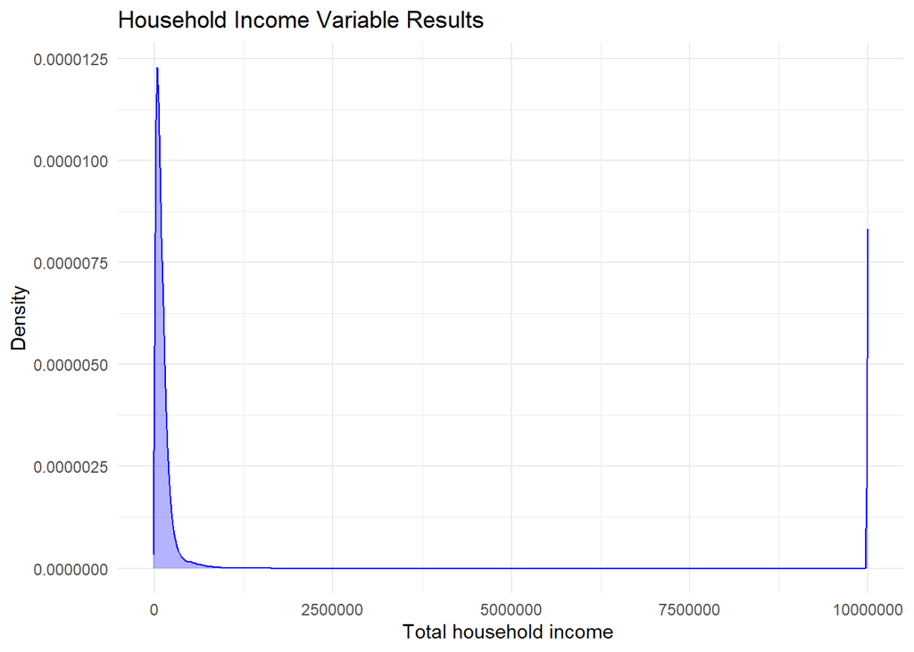

```r
acs_combined %>%
  ggplot(aes(x = hhincome)) +
  geom_density(color = "blue", fill = alpha("blue", 0.3)) +
  theme_minimal() +
  ggtitle("Household Income Variable Results") +
  ylab("Density")
```

Turn the missing/“not in universe” values for the `hhincome` variable into NAs. Rename to the more meaningful “household_income”.

```r
acs_clean <- acs_combined %>%
  mutate(household_income = ifelse(hhincome == 9999999, NA_integer_,
                          hhincome)
  )
```

Look at distribution of `household_income` after adjustment. Some outliers will still exist but bunching around the missing value should not be present.

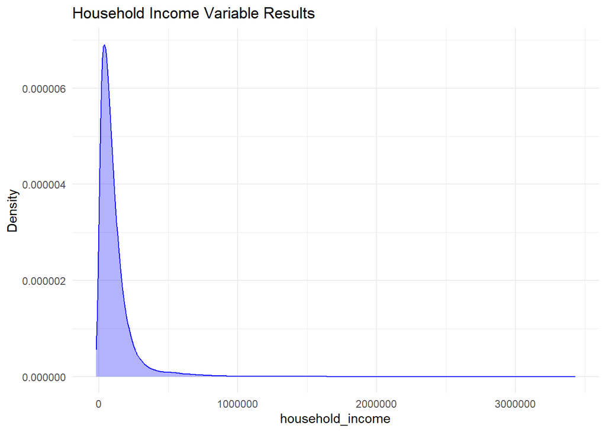

```r
acs_clean %>%
  ggplot(aes(x = household_income)) +
  geom_density(adjust = 5, color = "blue", fill = alpha("blue", 0.3)) +
  theme_minimal() +
  ggtitle("Household Income Variable Results") +
  ylab("Density")
```

Select our group quarters, we want to keep only households including additional households under the 2000 definition. With household income we do not consider group quarters.

```r
acs_clean %>%
  group_by(gq) %>%
  count()
```

```
# A tibble: 5 × 2
# Groups:   gq [5]
  gq                                                n
  <fct>                                         <int>
1 Households under 1970 definition            6227892
2 Additional households under 1990 definition    3933
3 Group quarters--Institutions                 402812
4 Other group quarters                         451530
5 Additional households under 2000 definition     321
```

```r
acs_clean <- acs_clean %>%
  filter(gq %in% c("Households under 1970 definition",
                   "Additional households under 1990 definition",
                   "Additional households under 2000 definition"))
```

Check that group quarters fall only into household categories.

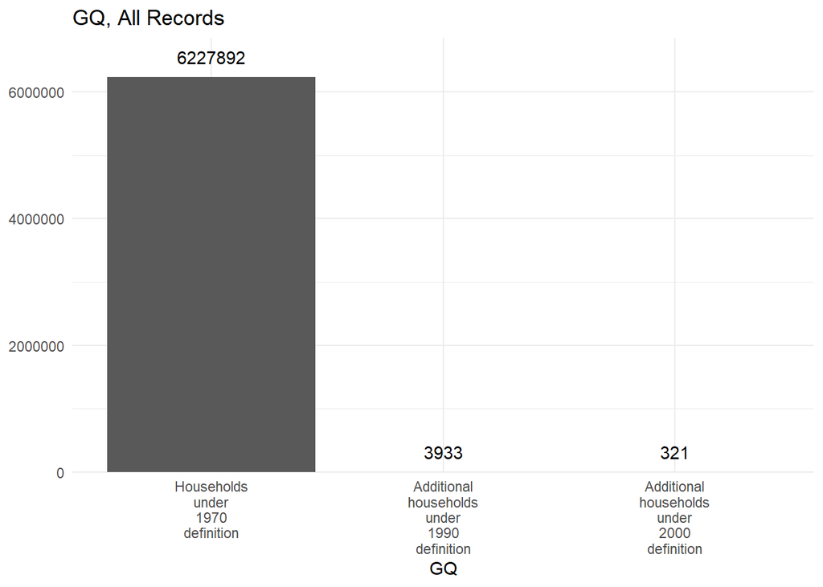

```r
acs_clean %>%
  count(gq) %>%
  ggplot(mapping = aes(x = gq, y = n)) +
  geom_col() +
  theme_minimal() +
  ggtitle("GQ, All Records") +
 geom_text(mapping = aes(label = n), vjust = -1) +
  scale_y_continuous(expand = expansion(mult = c(0, 0.1))) +
  labs(x = "GQ",
       y = NULL) +
  scale_x_discrete(labels = label_wrap(10))
```

### Create race variable

Evaluate the values in the RACE and HISPAN variables.

- IPUMS documented values for RACE:
  - 1 White
  - 2 Black/African American/Negro
  - 3 American Indian or Alaska Native
  - 4 Chinese
  - 5 Japanese
  - 6 Other Asian or Pacific Islander
  - 7 Other race
  - 8 Two major races
  - 9 Three or more major races
- IPUMS documented values for HISPAN:
  - 0 Not Hispanic
  - 1 Mexican
  - 2 Puerto Rican
  - 3 Cuban
  - 4 Other
  - 9 Not Reported

Look at the distribution of values for the race and hispan variables.

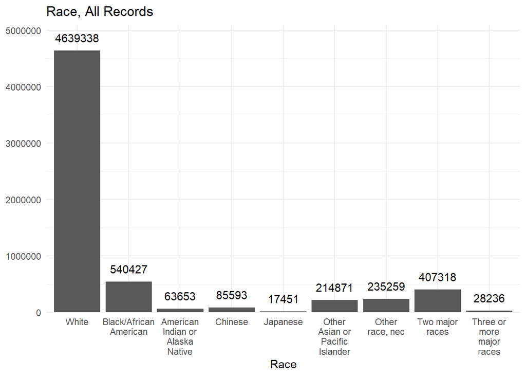

```r
acs_clean %>%
  count(race) %>%
  ggplot(mapping = aes(x = race, y = n)) +
  geom_col() +
  theme_minimal() +
  ggtitle("Race, All Records") +
 geom_text(mapping = aes(label = n), vjust = -1) +
  scale_y_continuous(expand = expansion(mult = c(0, 0.1))) +
  labs(x = "Race",
       y = NULL)+
  scale_x_discrete(labels = label_wrap(10))
```

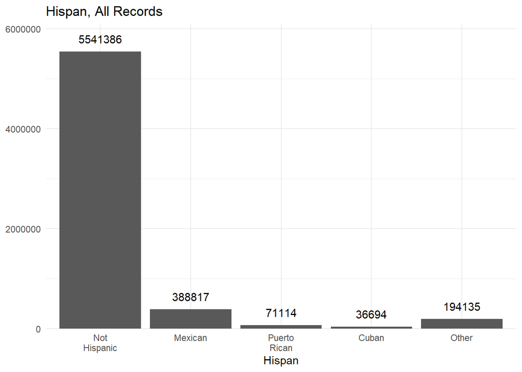

```r
acs_clean %>%
  count(hispan) %>%
  ggplot(mapping = aes(x = hispan, y = n)) +
  geom_col() +
  theme_minimal() +
  ggtitle("Hispan, All Records") +
 geom_text(mapping = aes(label = n), vjust = -1) +
  scale_y_continuous(expand = expansion(mult = c(0, 0.1))) +
  labs(x = "Hispan",
       y = NULL)+
  scale_x_discrete(labels = label_wrap(10))
```

Create the race/ethnicity variable. For race/ethnicity categories that are not coded as Hispanic, Hispan must be equal to “Not Hispanic”.

Rename the values from number category to race label: +Race is Black/African American and Hispan is Not Hispanic = “Black, Non-Hispanic” +Hispan is not equal to Not Hispanic = “Hispanic” +Race is not Black or White and Hispan is Not Hispanic = “Other Races and Ethnicities” +Race is White and Hispan is Not Hispanic = “White, Non-Hispanic”

```r
acs_clean <- acs_clean %>%
  mutate(
    subgroup_race = case_when(
      hispan != "Not Hispanic" ~ "Hispanic",
      race == "White" ~ "White, Non-Hispanic",
      race == "Black/African American" ~ "Black, Non-Hispanic",
      !race %in% c("Black/African American", "White") ~ "Other Races and Ethnicities"
    )
  )
```

Look at the race/ethnicity subgroup distribution.

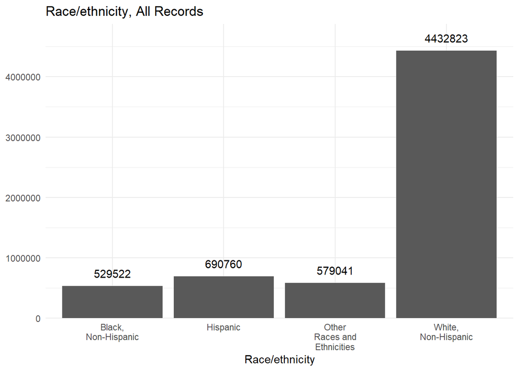

```r
acs_clean %>%
  count(subgroup_race) %>%
  ggplot(mapping = aes(x = factor(subgroup_race), y = n)) +
  geom_col() +
  theme_minimal() +
  ggtitle("Race/ethnicity, All Records") +
 geom_text(mapping = aes(label = n), vjust = -1) +
  scale_y_continuous(expand = expansion(mult = c(0, 0.1))) +
  labs(x = "Race/ethnicity",
       y = NULL)+
  scale_x_discrete(labels = label_wrap(10))
```

### Create gender variable

Evaluate the values in the gender variable.

- IPUMS documented values for SEX:
  - 1 Male
  - 2 Female
  - 9 Missing/blank

Look at the distribution of values for the sex variable. There are no missing values in the data and the records are reported in an appropriate format.

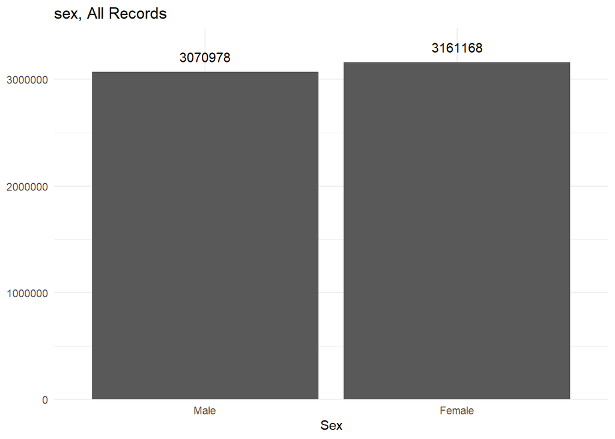

```r
acs_clean %>%
  count(sex) %>%
  ggplot(mapping = aes(x = sex, y = n)) +
  geom_col() +
  theme_minimal() +
  ggtitle("sex, All Records") +
 geom_text(mapping = aes(label = n), vjust = -1) +
  scale_y_continuous(expand = expansion(mult = c(0, 0.1))) +
  labs(x = "Sex",
       y = NULL)+
  scale_x_discrete(labels = label_wrap(10))
```

Rename the variable to subgroup_gender. The variable terms remain the same but any values outside of Male and Female are mutated to NA character variables. Though there are no missing values in the current data let’s leave this in the case of future ACS surveys including missing values for this variable.

```r
acs_clean <- acs_clean %>%
  mutate(subgroup_gender = case_when(sex == "Male" ~ "Male",
                                     sex == "Female" ~ "Female",
                                     TRUE ~ NA_character_))
```

## Crosswalk

Read in the PUMA to county crosswalk file. This file is created by the program generate_puma_county_crosswalks.rmd in the geographic-crosswalks folder.

```r
puma_county_crosswalk <- read_csv(
  here::here("geographic-crosswalks", "data", "crosswalk_puma_to_county.csv")
)
```

Create a version with just unique counties for creating a version of the data that matches the UMF county list.

```r
if(params$year < 2022){
  county_list <- puma_county_crosswalk %>%
    filter(crosswalk_period == "pre-2022") %>%
    select(statefip, county) %>%
    filter(statefip != 72) %>%
    unique()

}else{
  county_list <- puma_county_crosswalk %>%
  filter(crosswalk_period == "2022") %>%
  select(statefip, county) %>%
  filter(statefip != 72) %>%
  unique()
}
```

## Merge Crosswalk

Create a variable in the ACS data indicating whether the survey is pre or post-2022. This will be used to join on the correct crosswalk information.

```r
acs_clean <- acs_clean %>%
  mutate(crosswalk_period = ifelse(year < 2022, "pre-2022", "2022"))
```

Check that the assignment worked. All years prior to 2022 should be designated “pre-2022”.

```r
count(acs_clean, crosswalk_period, year)
```

```
# A tibble: 1 × 3
  crosswalk_period  year       n
  <chr>            <int>   <int>
1 2022              2023 6232146
```

Join the cleaned ACS data onto the crosswalk.

```r
acs_crosswalked <- left_join(
  acs_clean,
  puma_county_crosswalk,
  by = c("crosswalk_period", "statefip","puma"),
  relationship = "many-to-many"
)

rm(acs_clean)
```

Drop any observations with NA for `afact` (i.e. there is no county of interest overlapping this PUMA).

```r
count(acs_crosswalked, is.na(afact))
```

```
# A tibble: 1 × 2
  `is.na(afact)`        n
  <lgl>             <int>
1 FALSE          13749194
```

```r
acs_crosswalked <- acs_crosswalked %>%
  drop_na(afact)
```

Also filter out cases where `afact` is equal to zero. These cases will not be counted in the metric calculation.

```r
count(acs_crosswalked, afact == 0)
```

```
# A tibble: 1 × 2
  `afact == 0`        n
  <lgl>           <int>
1 FALSE        13749194
```

```r
acs_crosswalked <- acs_crosswalked %>%
  filter(afact > 0)
```

Adjust the household weight to account for PUMA-to-county mapping (those where the PUMA is not entirely inside the county).

```r
select(acs_crosswalked, hhwt, repwt1, repwt80, afact)
```

```
# A tibble: 13,749,194 × 4
    hhwt repwt1 repwt80 afact
   <dbl>  <dbl>   <dbl> <dbl>
 1    78     81     128 1
 2    13     21      24 1
 3    29     28      28 0.107
 4    29     28      28 0.113
 5    29     28      28 0.165
 6    29     28      28 0.616
 7    14     16       7 0.194
 8    14     16       7 0.806
 9    23     23      24 1
10     4      4       2 0.176
# ℹ 13,749,184 more rows
```

```r
acs_crosswalked <- acs_crosswalked %>%
  mutate(hhwt = hhwt * afact,
         across(matches("repwt[0-9]+"), ~.x * afact))

select(acs_crosswalked, hhwt, repwt1, repwt80, afact)
```

```
# A tibble: 13,749,194 × 4
     hhwt repwt1 repwt80 afact
    <dbl>  <dbl>   <dbl> <dbl>
 1 78     81     128     1
 2 13     21      24     1
 3  3.09   2.99    2.99  0.107
 4  3.27   3.16    3.16  0.113
 5  4.78   4.61    4.61  0.165
 6 17.9   17.2    17.2   0.616
 7  2.72   3.11    1.36  0.194
 8 11.3   12.9     5.64  0.806
 9 23     23      24     1
10  0.706  0.706   0.353 0.176
# ℹ 13,749,184 more rows
```

### Inflation Adjustment

This section makes two adjustments to then dollar `household_income` values that account for inflation. First, we apply CPI adjustments for all values to the latest year in dollar value.

This adjustment table is provided by the [IPUMS website](https://usa.ipums.org/usa/cpi99.shtml). IPUMS updates this table for new ACS years annually, users may have to update the link in the ‘read_html’ statement below.

```r
cpi_data <- rvest::read_html("https://usa.ipums.org/usa/cpi99.shtml") %>%
    rvest::html_element("table") %>%
    rvest::html_table() %>%
    janitor::clean_names() %>%
    select(data_year, income_year, cpi_to_1999 = cpi99) %>%
    mutate(
      data_year = as.numeric(data_year),
      income_year = parse_number(income_year),
      cpi_to_1999 = as.numeric(cpi_to_1999)
    ) %>%
    filter(!is.na(data_year)) # drop the second 2000 row which gets parsed as NA due to a trailing space
```

Convert all values to 1999 dollars.

```r
acs_crosswalked <- acs_crosswalked %>%
  left_join(cpi_data, by = c("year" = "data_year")) %>%
  mutate(
    household_income = household_income*cpi_to_1999
  ) %>%
  select(-cpi_to_1999)
```

Now we want to adjust all values to the latest year available. This value comes from adjustment values also provided by [IPUMS](https://cps.ipums.org/cps/cpi99.shtml) and is scraped below. We adjust all values to the inflation year set in the parameters argument.

```r
cpi_data <- rvest::read_html("https://cps.ipums.org/cps/cpi99.shtml") %>%
    rvest::html_nodes("table") %>%
    rvest::html_table()

alternate_factor <- cpi_data[[2]] %>%
    janitor::clean_names() %>%
    select(income_year, alternate_factor) %>%
    mutate(
      income_year = str_sub(income_year, 1, 4),
      income_year = as.numeric(income_year),
      alternate_factor = as.numeric(alternate_factor)
    ) %>%
  filter(income_year == params$inflation_year) %>%
  select(alternate_factor) %>%
  pull()
```

```r
acs_crosswalked <- acs_crosswalked %>%
  mutate(
    household_income = household_income*alternate_factor
  )
```

Apply the Adjust variable to `household_income`. Adjust converts the dollar amounts to the amount that they would have been had they been earned entirely during the calendar year. This is to deal with households being surveyed at different times during the year.

```r
acs_crosswalked <- acs_crosswalked %>%
  mutate(
    household_income = household_income*adjust
  )
```

Check if `household_income` is ever `NA`.

```r
stopifnot(sum(is.na(acs_crosswalked$household_income)) == 0)
```

Confirm there are no vacant properties included in the data.

```r
stopifnot(sum(is.na(acs_crosswalked$vacancy)) == 0)
```

## Create income metric: All

Create the income metric.

Objective: calculate the 20th, 50th and 80th quantiles of income by county for all households.

Aggregation should be weighted by HHWT (this is a household level statistic).

### Pre-drop suppressed cells

First, to save time when processing the metric, calculate the effective sample count for each county, defined as the sum of the `afact` variable. This is used to create a cutoff for data quality based on the actual number of survey records being used in the calculation. We will not include counties with less than 30 effective samples.

```r
acs_all <- acs_crosswalked %>%
  group_by(year, sample, crosswalk_period, statefip, county) %>%
  mutate(effective_sample = sum(afact)) %>%
  ungroup()

# calculate the number of statistics after suppressing values
acs_all %>%
  group_by(year, sample, crosswalk_period, statefip, county) %>%
  summarise(
    effective_sample = max(effective_sample)
  ) %>%
  ungroup() %>%
  summarise(
    original_stats = n(),
    unsuppressed_stats = sum(effective_sample >= 30)
  )
```

```
# A tibble: 1 × 2
  original_stats unsuppressed_stats
           <int>              <int>
1           3144               3097
```

Remove records from counties below the size quality cutoff.

```r
acs_all <- acs_all %>%
  filter(effective_sample >= 30)
```

### Calculate metric

Calculate the county-level metrics.

```r
results_all <- acs_all %>%
  group_split(statefip) %>%
  map_dfr(~ calc_income_quantiles(.data = .x, .geo_level = county))
```

Clean up the confidence interval bounds and sort the data.

```r
results_all <- finalize_metric(results_all,
                               .geo_level = county)
```

```r
rm(acs_all)
```

## Add Suppressed Rows to Data

To create the metric we suppressed counties that did not meet the threshold for sample size but we need to include these in the final data. Create an all version of the data that includes counties that were suppressed prior to the survey_mean calculation.

```r
expanded_county_list <- county_list %>%
  left_join(results_all, by = c("statefip", "county"), relationship = "many-to-many") %>%
  mutate(geoid = paste0(statefip, county)) %>%
  expand(year, geoid) %>%
  mutate(statefip = str_sub(geoid, 1, 2),
         county = str_sub(geoid, 3, 5))

results_all_expand <- expanded_county_list %>%
  left_join(results_all, by = c("year", "statefip", "county")) %>%
  filter(!is.na(year))

if(params$year < 2022){
stopifnot(nrow(results_all_expand) == 3143 * n_distinct(results_all_expand$year))
}else{
  stopifnot(nrow(results_all_expand) == 3144 * n_distinct(results_all_expand$year))
}
```

## Create income metric: subgroups

## Race/Ethnicity

To save time when processing the metric, calculate the effective sample count for each race-ethnicity group in each county, defined as the sum of the `afact` variable. This is used to create a cutoff for data quality based on the actual number of survey records being used in the calculation. We will not include counties with less than 30 effective samples.

```r
acs_race_ethnicity <- acs_crosswalked %>%
  group_by(year, sample, crosswalk_period, statefip, county, subgroup_race) %>%
  mutate(effective_sample = sum(afact)) %>%
  ungroup()
# calculate the number of statistics after suppressing values
acs_race_ethnicity %>%
  group_by(year, sample, crosswalk_period, statefip, county, subgroup_race) %>%
  summarise(
    effective_sample = max(effective_sample)
  ) %>%
  ungroup() %>%
  summarise(
    original_stats = n(),
    unsuppressed_stats = sum(effective_sample >= 30)
  )
```

```
# A tibble: 1 × 2
  original_stats unsuppressed_stats
           <int>              <int>
1          12573               6934
```

Create the income metric for the race/ethnicity subgroup.

Remove records from counties below the size quality cutoff.

```r
acs_race_ethnicity <- acs_race_ethnicity %>%
  filter(effective_sample >= 30)
```

### Calculate metric

```r
results_race_ethnicity <- acs_race_ethnicity %>%
  group_split(statefip) %>%
  map_dfr(~ calc_income_quantiles_subgroup(.data = .x,
                                      .geo_level = county,
                                      .subgroup = subgroup_race))
```

```r
results_race_ethnicity <- finalize_metric(results_race_ethnicity,
                                          .geo_level = county)
```

```r
rm(acs_race_ethnicity)
```

### Add Suppressed Rows to Data

To create the metric we suppressed counties that did not meet the threshold for sample size but we need to include these in the final data. Create an all version of the data that includes counties that were suppressed prior to the survey_mean calculation.

Create expanded version for race-ethnicity.

```r
expanded_county_list_race <- county_list %>%
  left_join(results_race_ethnicity, by = c("statefip", "county"), relationship = "many-to-many") %>%
  mutate(geoid = paste0(statefip, county)) %>%
  expand(year, geoid, subgroup_race) %>%
  mutate(statefip = str_sub(geoid, 1, 2),
         county = str_sub(geoid, 3, 5))

results_race_ethnicity_expanded <- expanded_county_list_race  %>%
  left_join(results_race_ethnicity, by = c("year", "statefip", "county", "subgroup_race")) %>%
  filter(!is.na(year), !is.na(subgroup_race)) %>%
  mutate(subgroup_type = "race-ethnicity") %>%
  rename(subgroup = subgroup_race)

if(params$year < 2022){
stopifnot(nrow(results_race_ethnicity_expanded) == 3143 * n_distinct(results_race_ethnicity_expanded$year) * 4)
}else{
  stopifnot(nrow(results_race_ethnicity_expanded) == 3144 * n_distinct(results_race_ethnicity_expanded$year) * 4)
}
```

## Gender

To save time when processing the metric, calculate the effective sample count for each gender group in each county, defined as the sum of the `afact` variable. This is used to create a cutoff for data quality based on the actual number of survey records being used in the calculation. We will not include counties with less than 30 effective samples.

```r
acs_gender <- acs_crosswalked %>%
  group_by(year, sample, crosswalk_period, statefip, county, subgroup_gender) %>%
  mutate(effective_sample = sum(afact)) %>%
  ungroup()
# calculate the number of statistics after suppressing values
acs_gender %>%
  group_by(year, sample, crosswalk_period, statefip, county, subgroup_gender) %>%
  summarise(
    effective_sample = max(effective_sample)
  ) %>%
  ungroup() %>%
  summarise(
    original_stats = n(),
    unsuppressed_stats = sum(effective_sample >= 30)
  )
```

```
# A tibble: 1 × 2
  original_stats unsuppressed_stats
           <int>              <int>
1           6288               6027
```

Remove records from counties below the size quality cutoff.

```r
acs_gender <- acs_gender %>%
  filter(effective_sample >= 30)
```

### Calculate metric

```r
results_gender <- acs_gender %>%
  group_split(statefip) %>%
  map_dfr(~ calc_income_quantiles_subgroup(.data = .x,
                                      .geo_level = county,
                                      .subgroup = subgroup_gender))
```

```r
results_gender <- finalize_metric(results_gender,
                                  .geo_level = county)
```

```r
rm(acs_gender)
```

### Add Suppressed Rows to Data

Create expanded version for gender.

```r
expanded_county_list_gender <- county_list %>%
  left_join(results_gender, by = c("statefip", "county"), relationship = "many-to-many") %>%
  mutate(geoid = paste0(statefip, county)) %>%
  expand(year, geoid, subgroup_gender) %>%
  mutate(statefip = str_sub(geoid, 1, 2),
         county = str_sub(geoid, 3, 5))

results_gender_expanded <- expanded_county_list_gender  %>%
  left_join(results_gender, by = c("year", "statefip", "county", "subgroup_gender")) %>%
  filter(!is.na(year), !is.na(subgroup_gender)) %>%
  mutate(subgroup_type = "gender") %>%
  rename(subgroup = subgroup_gender)

if(params$year < 2022){
stopifnot(nrow(results_gender_expanded) == 3143 * n_distinct(results_gender_expanded$year) * 2)
}else{
  stopifnot(nrow(results_gender_expanded) == 3144 * n_distinct(results_gender_expanded$year) * 2)
}
```

## Data Quality Flags

Add a flag for data quality, this is a numeric variable between 1 and 3 with 1 representing the best quality and 3 representing the worst.

First combine the subgroup data sets.

```r
metrics_income_sub <- results_all_expand %>%
  mutate(subgroup = "All",
         subgroup_type = "all") %>%
  bind_rows(results_race_ethnicity_expanded) %>%
  bind_rows(results_gender_expanded)
```

Add a flag for data quality, this is a numeric variable between 1 and 3 with 1 representing the best quality and 3 representing the worst.

The data quality flag is based on the allocation of the PUMAs that make up a county, which comes from the crosswalk file, and the effective sample size of the county. When the effective sample size is less than 30 all records for that county will be reported as `NA`, including `pctl_income_quality`.

```r
metrics_income_sub <- metrics_income_sub %>%
  mutate(
   pctl_income_20_quality = if_else(
      is.na(pctl_income_20),
      NA_real_,
      geographic_allocation_quality
    ),
    pctl_income_50_quality = if_else(
      is.na(pctl_income_50),
      NA_real_,
      geographic_allocation_quality
    ),
    pctl_income_80_quality = if_else(
      is.na(pctl_income_80),
      NA_real_,
      geographic_allocation_quality
    )
  )
```

### Write out intermediate data

```r
if(isTRUE(bucket_exists(bucket = my_bucket))){
    # write file to S3
    tmp <- tempfile()
    on.exit(unlink(tmp))
    write_csv(metrics_income_sub, file = tmp)

    # put object with an upload progress bar
    put_object(tmp, object = paste0(s3_dir, "/metrics_income_county_sub", "_", params$year, ".csv"), bucket = my_bucket,
               show_progress = TRUE, multipart = FALSE)
}
```

```
[1] TRUE
```

If updating a single year the program ends here. To see validation results re-run with selection that all years of intermediate data are available.

```r
if(single_year_update == "Yes"){
  knitr::knit_exit()
}
```

## Validation

Validate and test the results.

### Read intermediate files

Read in the intermediate files created for each ACS year available.

Function reads the CSVs from intermediate folder or from AWS if the user has access.

```r
read_intermediate <- function(year, file_type){

  if(isTRUE(bucket_exists(bucket = my_bucket))) {

    s3read_using(FUN=read_csv,
                 bucket = my_bucket,
                 object=paste0(s3_dir, "/metrics_income_county_", file_type, "_", year, ".csv")) %>%
      mutate(crosswalk_period = as.character(crosswalk_period))

  }
  else{

  read_csv(paste0(here::here("03_opportunities-for-income", "data", "intermediate", "income"),
                  "/", "metrics_income_county_", file_type, "_", year, ".csv"))
  }

}
```

```r
metrics_income_sub <- map_df(.x = existing_years, .f = ~read_intermediate(year = .x,
                                                                          file_type = "sub"))
```

### Summaries and Visualization

Summarize the predictors for 5-year data.

```r
metrics_income_sub %>%
  select(pctl_income_20:pctl_income_80) %>%
  summary()
```

```
 pctl_income_20   pctl_income_50   pctl_income_80
 Min.   :    21   Min.   : 14926   Min.   : 46253
 1st Qu.: 21983   1st Qu.: 53019   1st Qu.:105992
 Median : 27166   Median : 63056   Median :120327
 Mean   : 28153   Mean   : 64616   Mean   :124457
 3rd Qu.: 32763   3rd Qu.: 73091   3rd Qu.:135952
 Max.   :113927   Max.   :237573   Max.   :427770
 NA's   :32071    NA's   :32071    NA's   :32071
```

Look at distributions of income percentiles by county for all (latest year).

[figure not shown]

```r
metrics_income_sub %>%
  filter(year == params$year, subgroup == "all") %>%
  select(pctl_income_20, pctl_income_50, pctl_income_80) %>%
  pivot_longer(cols = c(pctl_income_20, pctl_income_50, pctl_income_80),
               names_to = "income", values_to = "percentile") %>%
  ggplot(aes(x = percentile, color = income, fill = income)) +
  geom_density(alpha = 0.15) +
  theme_minimal() +
  ggtitle(paste0("Income percentiles", params$year, "(5-year data)")) +
  ylab("Density")
```

Break out distributions by subgroup (latest year).

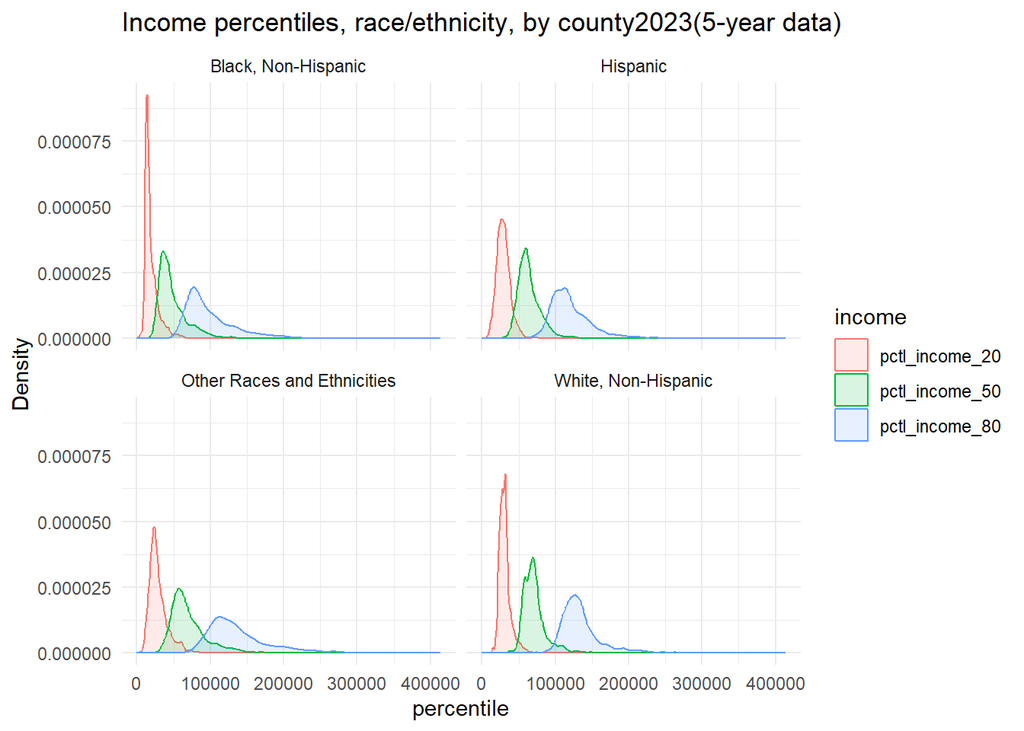

```r
metrics_income_sub %>%
  filter(year == params$year, subgroup_type == "race-ethnicity") %>%
  select(subgroup, county, pctl_income_20, pctl_income_50, pctl_income_80) %>%
  pivot_longer(cols = c(pctl_income_20, pctl_income_50, pctl_income_80),
               names_to = "income", values_to = "percentile") %>%
  ggplot(aes(x = percentile, color = income, fill = income)) +
  geom_density(alpha = 0.15) +
  facet_wrap(~subgroup) +
  labs(
    title = paste0("Income percentiles, race/ethnicity, by county", params$year, "(5-year data)"),
    y = "Density"
  ) +
  theme_minimal()
```

Median income for select counties over time by race and ethnicity

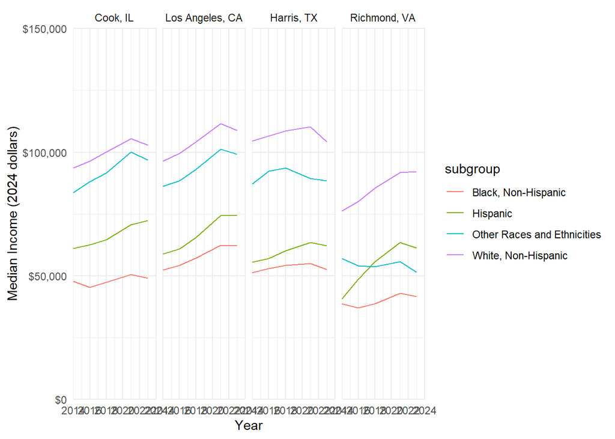

```r
metrics_income_sub %>%
  filter(subgroup_type == "race-ethnicity") %>%
  mutate(countyfip = paste0(statefip, county)) %>%
  filter(countyfip %in% c("17031", "06037", "48201", "51760")) %>%
  mutate(county = case_when(countyfip == "17031" ~ "Cook, IL",
                            countyfip == "06037" ~ "Los Angeles, CA",
                            countyfip == "48201" ~ "Harris, TX",
                            countyfip == "51760" ~ "Richmond, VA"),
         county = factor(county, levels = c("Cook, IL",
                                            "Los Angeles, CA",
                                            "Harris, TX",
                                            "Richmond, VA"))) %>%
  ggplot(aes(year, pctl_income_50, color = subgroup)) +
  geom_line() +
  facet_wrap(~county, ncol = 4) +
  scale_x_continuous(expand = expansion(mult = c(0.002, 0)),
                     limits = c(2014, 2024)) +
  scale_y_continuous(expand = expansion(mult = c(0, 0.002)),
                     labels = scales::dollar,
                     limits = c(0, 150000)) +
  labs(x = "Year",
       y = "Median Income (2024 dollars)")
```

80th percentile income for select counties over time by race and ethnicity

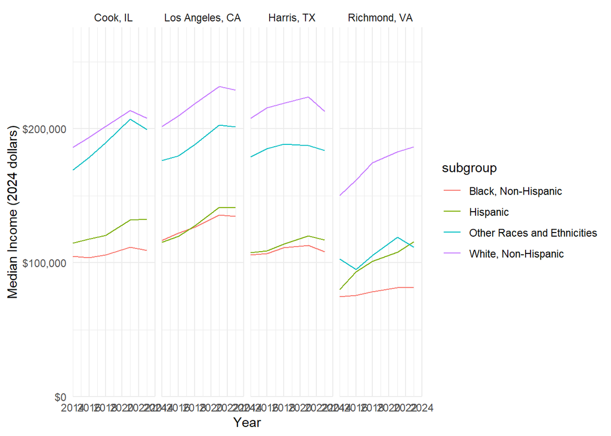

```r
metrics_income_sub %>%
  filter(subgroup_type == "race-ethnicity") %>%
  mutate(countyfip = paste0(statefip, county)) %>%
  filter(countyfip %in% c("17031", "06037", "48201", "51760")) %>%
  mutate(county = case_when(countyfip == "17031" ~ "Cook, IL",
                            countyfip == "06037" ~ "Los Angeles, CA",
                            countyfip == "48201" ~ "Harris, TX",
                            countyfip == "51760" ~ "Richmond, VA"),
         county = factor(county, levels = c("Cook, IL",
                                            "Los Angeles, CA",
                                            "Harris, TX",
                                            "Richmond, VA"))) %>%
  ggplot(aes(year, pctl_income_80, color = subgroup)) +
  geom_line() +
  facet_wrap(~county, ncol = 4) +
  scale_x_continuous(expand = expansion(mult = c(0.002, 0)),
                     limits = c(2014, 2024)) +
  scale_y_continuous(expand = expansion(mult = c(0, 0.002)),
                     labels = scales::dollar,
                     limits = c(0, 275000)) +
  labs(x = "Year",
       y = "Median Income (2024 dollars)")
```

Median income for select counties over time by gender

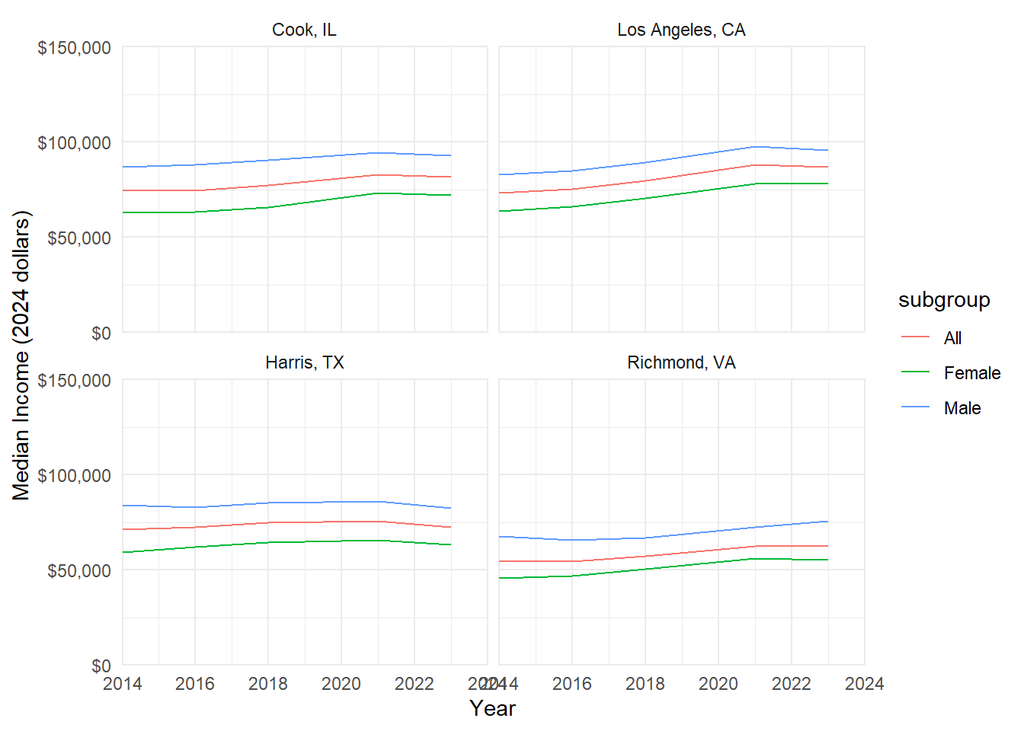

```r
metrics_income_sub %>%
  filter(subgroup_type %in% c("gender", "all")) %>%
 mutate(countyfip = paste0(statefip, county)) %>%
  filter(countyfip %in% c("17031", "06037", "48201", "51760")) %>%
  mutate(county = case_when(countyfip == "17031" ~ "Cook, IL",
                            countyfip == "06037" ~ "Los Angeles, CA",
                            countyfip == "48201" ~ "Harris, TX",
                            countyfip == "51760" ~ "Richmond, VA"),
         county = factor(county, levels = c("Cook, IL",
                                            "Los Angeles, CA",
                                            "Harris, TX",
                                            "Richmond, VA"))) %>%
  ggplot(aes(year, pctl_income_50, color = subgroup)) +
  geom_line() +
  facet_wrap(~county, ncol = 2) +
  scale_x_continuous(expand = expansion(mult = c(0.002, 0)),
                     limits = c(2014, 2024)) +
  scale_y_continuous(expand = expansion(mult = c(0, 0.002)),
                     labels = scales::dollar,
                     limits = c(0, 150000)) +
  labs(x = "Year",
       y = "Median Income (2024 dollars)")
```

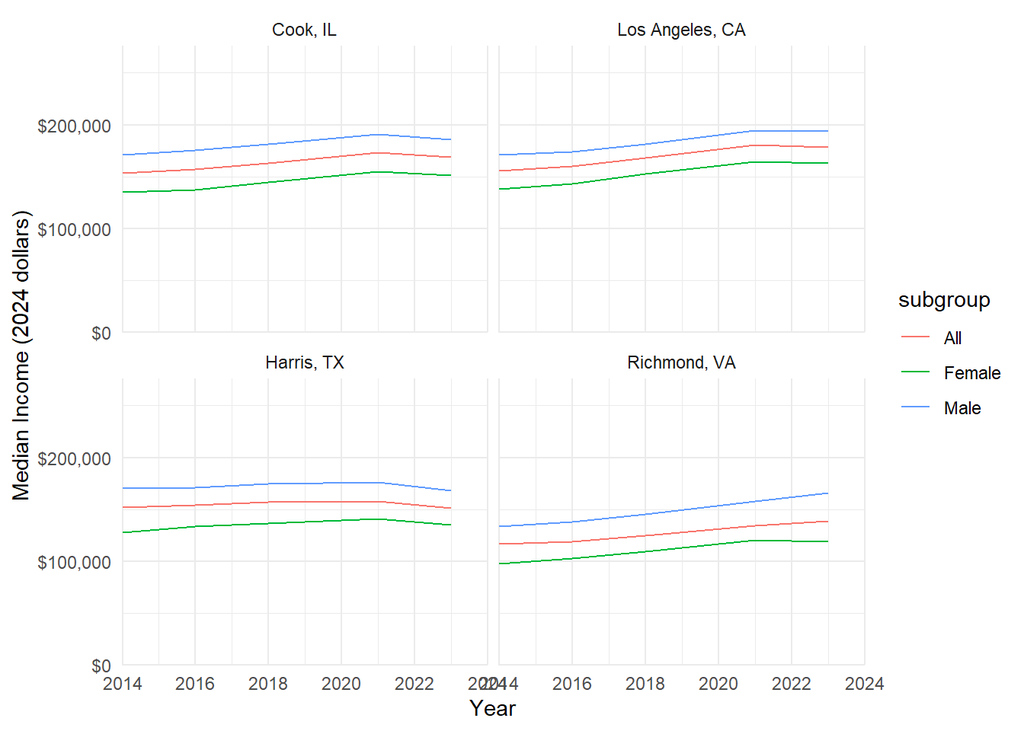

```r
metrics_income_sub %>%
  filter(subgroup_type %in% c("gender", "all")) %>%
  mutate(countyfip = paste0(statefip, county)) %>%
  filter(countyfip %in% c("17031", "06037", "48201", "51760")) %>%
  mutate(county = case_when(countyfip == "17031" ~ "Cook, IL",
                            countyfip == "06037" ~ "Los Angeles, CA",
                            countyfip == "48201" ~ "Harris, TX",
                            countyfip == "51760" ~ "Richmond, VA"),
         county = factor(county, levels = c("Cook, IL",
                                            "Los Angeles, CA",
                                            "Harris, TX",
                                            "Richmond, VA"))) %>%
  ggplot(aes(year, pctl_income_80, color = subgroup)) +
  geom_line() +
  facet_wrap(~county, ncol = 2) +
  scale_x_continuous(expand = expansion(mult = c(0.002, 0)),
                     limits = c(2014, 2024)) +
  scale_y_continuous(expand = expansion(mult = c(0, 0.002)),
                     labels = scales::dollar,
                     limits = c(0, 275000)) +
  labs(x = "Year",
       y = "Median Income (2024 dollars)")
```

Look at the counts of the quality flag (all years). We look at quality for `pctl_income_20`, given how the quality variable is created it will be identical to the quality results for income_50 and income_80.

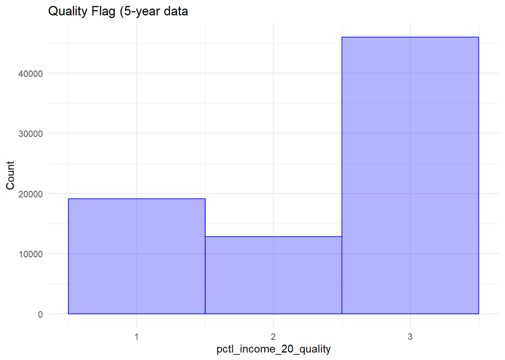

```r
metrics_income_sub %>%
  select(pctl_income_20_quality) %>%
  ggplot(aes(x = pctl_income_20_quality)) +
  geom_histogram(color = "blue", fill = alpha("blue", 0.3), binwidth = 1.0) +
  theme_minimal() +
  ggtitle("Quality Flag (5-year data") +
  ylab("Count")
```

Tabulate share of data suppressed by year.

```r
metrics_income_sub %>%
  group_by(year) %>%
  filter(is.na(pctl_income_20)) %>%
  count()
```

```
# A tibble: 5 × 2
# Groups:   year [5]
   year     n
  <dbl> <int>
1  2014  6713
2  2016  6600
3  2018  6544
4  2021  6264
5  2023  5950
```

## Final Test and Export

Rename state.

```r
metrics_income_sub <- metrics_income_sub %>%
  rename("state" = "statefip")
```

Order the variables how we want.

```r
metrics_income_sub <- metrics_income_sub %>%
  select(year, state, county, subgroup_type, subgroup, pctl_income_20, pctl_income_20_lb,
         pctl_income_20_ub,
         pctl_income_20_quality,
         pctl_income_50, pctl_income_50_lb,
         pctl_income_50_ub,
         pctl_income_50_quality,
         pctl_income_80, pctl_income_80_lb,
         pctl_income_80_ub,
         pctl_income_80_quality)
```

Run file through evaluate final data function.

Gender

```r
metrics_income_gender <- metrics_income_sub %>%
  filter(subgroup_type %in% c("all", "gender"))

evaluate_final_data(data = metrics_income_gender, exp_form_path = here::here("10a_final-evaluation", "evaluation_form_income_gender_county.csv"), geography = "county", subgroups = TRUE, confidence_intervals = TRUE)
```

```
[1] "This data passes all tests!"
```

Race-ethnicity

```r
metrics_income_race <- metrics_income_sub %>%
  filter(subgroup_type %in% c("all", "race-ethnicity"))

evaluate_final_data(data = metrics_income_race, exp_form_path = here::here("10a_final-evaluation", "evaluation_form_income_race_eth_county.csv"), geography = "county", subgroups = TRUE, confidence_intervals = TRUE)
```

```
[1] "This data passes all tests!"
```

### Export as CSV

Export as CSV.

```r
metrics_income_gender %>%
  head(10)
```

```
# A tibble: 10 × 17
    year state county subgroup_type subgroup pctl_income_20 pctl_income_20_lb
   <dbl> <chr> <chr>  <chr>         <chr>             <dbl>             <dbl>
 1  2014 01    001    all           All              22507.            21055.
 2  2014 01    003    all           All              25399.            24062.
 3  2014 01    005    all           All              22458.            20670.
 4  2014 01    007    all           All              16989.            15647.
 5  2014 01    009    all           All              27166.            24876.
 6  2014 01    011    all           All              22458.            20670.
 7  2014 01    013    all           All              23524.            21964.
 8  2014 01    015    all           All              18933.            17646.
 9  2014 01    017    all           All              19966.            18441.
10  2014 01    019    all           All              20052.            18777.
# ℹ 10 more variables: pctl_income_20_ub <dbl>, pctl_income_20_quality <dbl>,
#   pctl_income_50 <dbl>, pctl_income_50_lb <dbl>, pctl_income_50_ub <dbl>,
#   pctl_income_50_quality <dbl>, pctl_income_80 <dbl>,
#   pctl_income_80_lb <dbl>, pctl_income_80_ub <dbl>,
#   pctl_income_80_quality <dbl>
```

```r
write_csv(metrics_income_gender, here::here("03_opportunities-for-income", "final", "metrics_income_county_gender_longitudinal.csv"))

metrics_income_race %>%
  head(10)
```

```
# A tibble: 10 × 17
    year state county subgroup_type subgroup pctl_income_20 pctl_income_20_lb
   <dbl> <chr> <chr>  <chr>         <chr>             <dbl>             <dbl>
 1  2014 01    001    all           All              22507.            21055.
 2  2014 01    003    all           All              25399.            24062.
 3  2014 01    005    all           All              22458.            20670.
 4  2014 01    007    all           All              16989.            15647.
 5  2014 01    009    all           All              27166.            24876.
 6  2014 01    011    all           All              22458.            20670.
 7  2014 01    013    all           All              23524.            21964.
 8  2014 01    015    all           All              18933.            17646.
 9  2014 01    017    all           All              19966.            18441.
10  2014 01    019    all           All              20052.            18777.
# ℹ 10 more variables: pctl_income_20_ub <dbl>, pctl_income_20_quality <dbl>,
#   pctl_income_50 <dbl>, pctl_income_50_lb <dbl>, pctl_income_50_ub <dbl>,
#   pctl_income_50_quality <dbl>, pctl_income_80 <dbl>,
#   pctl_income_80_lb <dbl>, pctl_income_80_ub <dbl>,
#   pctl_income_80_quality <dbl>
```

```r
write_csv(metrics_income_race, here::here("03_opportunities-for-income", "final", "metrics_income_county_race-ethnicity_longitudinal.csv"))
```